# Codebook for combined

2020-04-26 14:12:34

This dataset is the combined ‘train’ and ‘test’ datasets, after having: 1. Added the train and test subjects as the first variable 2. Added the descriptive activity as the second variable 3. Renaming the variables to be descriptive as detailed in ‘features.txt’

# Data report overview

The dataset examined has the following dimensions:

| Feature | Result |
| --- | --- |
| Number of observations | 10299 |
| Number of variables | 81 |

# Codebook summary table

| Label | Variable | Class | # unique values | Missing | Description |
| --- | --- | --- | --- | --- | --- |
|  | **subject** | integer | 30 | 0.00 % |  |
|  | **activity** | factor | 6 | 0.00 % |  |
|  | **tBodyAcc-mean()-X** | numeric | 10292 | 0.00 % |  |
|  | **tBodyAcc-mean()-Y** | numeric | 10299 | 0.00 % |  |
|  | **tBodyAcc-mean()-Z** | numeric | 10293 | 0.00 % |  |
|  | **tBodyAcc-std()-X** | numeric | 10295 | 0.00 % |  |
|  | **tBodyAcc-std()-Y** | numeric | 10297 | 0.00 % |  |
|  | **tBodyAcc-std()-Z** | numeric | 10297 | 0.00 % |  |
|  | **tGravityAcc-mean()-X** | numeric | 10296 | 0.00 % |  |
|  | **tGravityAcc-mean()-Y** | numeric | 10298 | 0.00 % |  |
|  | **tGravityAcc-mean()-Z** | numeric | 10299 | 0.00 % |  |
|  | **tGravityAcc-std()-X** | numeric | 10288 | 0.00 % |  |
|  | **tGravityAcc-std()-Y** | numeric | 10293 | 0.00 % |  |
|  | **tGravityAcc-std()-Z** | numeric | 10296 | 0.00 % |  |
|  | **tBodyAccJerk-mean()-X** | numeric | 10299 | 0.00 % |  |
|  | **tBodyAccJerk-mean()-Y** | numeric | 10299 | 0.00 % |  |
|  | **tBodyAccJerk-mean()-Z** | numeric | 10299 | 0.00 % |  |
|  | **tBodyAccJerk-std()-X** | numeric | 10290 | 0.00 % |  |
|  | **tBodyAccJerk-std()-Y** | numeric | 10296 | 0.00 % |  |
|  | **tBodyAccJerk-std()-Z** | numeric | 10293 | 0.00 % |  |
|  | **tBodyGyro-mean()-X** | numeric | 10298 | 0.00 % |  |
|  | **tBodyGyro-mean()-Y** | numeric | 10299 | 0.00 % |  |
|  | **tBodyGyro-mean()-Z** | numeric | 10297 | 0.00 % |  |
|  | **tBodyGyro-std()-X** | numeric | 10292 | 0.00 % |  |
|  | **tBodyGyro-std()-Y** | numeric | 10296 | 0.00 % |  |
|  | **tBodyGyro-std()-Z** | numeric | 10296 | 0.00 % |  |
|  | **tBodyGyroJerk-mean()-X** | numeric | 10295 | 0.00 % |  |
|  | **tBodyGyroJerk-mean()-Y** | numeric | 10299 | 0.00 % |  |
|  | **tBodyGyroJerk-mean()-Z** | numeric | 10298 | 0.00 % |  |
|  | **tBodyGyroJerk-std()-X** | numeric | 10292 | 0.00 % |  |

[output cut: 51 more lines]

# Variable list

## subject

| Feature | Result |
| --- | --- |
| Variable type | integer |
| Number of missing obs. | 0 (0 %) |
| Number of unique values | 30 |
| Median | 17 |
| 1st and 3rd quartiles | 9; 24 |
| Min. and max. | 1; 30 |

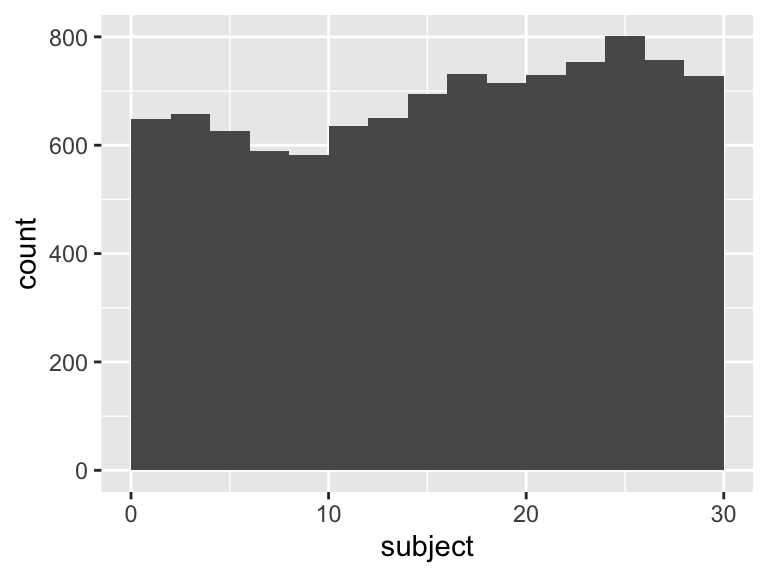

## activity

| Feature | Result |
| --- | --- |
| Variable type | factor |
| Number of missing obs. | 0 (0 %) |
| Number of unique values | 6 |
| Mode | “LAYING” |
| Reference category | WALKING |

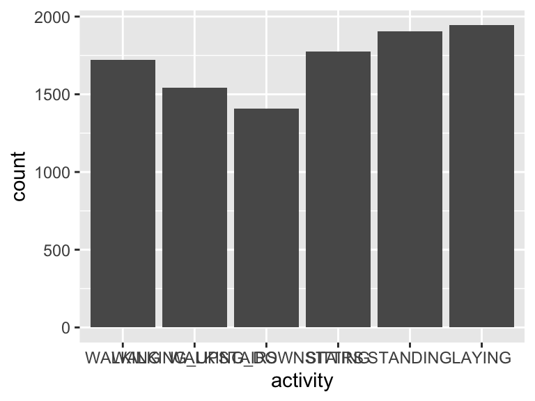

- Observed factor levels: "LAYING", "SITTING", "STANDING", "WALKING", "WALKING_DOWNSTAIRS", "WALKING_UPSTAIRS".

## tBodyAcc-mean()-X

| Feature | Result |
| --- | --- |
| Variable type | numeric |
| Number of missing obs. | 0 (0 %) |
| Number of unique values | 10292 |
| Median | 0.28 |
| 1st and 3rd quartiles | 0.26; 0.29 |
| Min. and max. | -1; 1 |

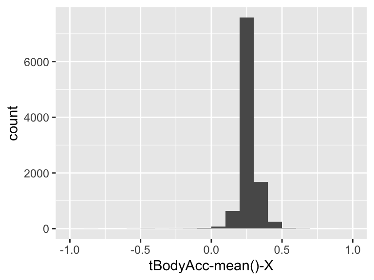

## tBodyAcc-mean()-Y

| Feature | Result |
| --- | --- |
| Variable type | numeric |
| Number of missing obs. | 0 (0 %) |
| Number of unique values | 10299 |
| Median | -0.02 |
| 1st and 3rd quartiles | -0.02; -0.01 |
| Min. and max. | -1; 1 |

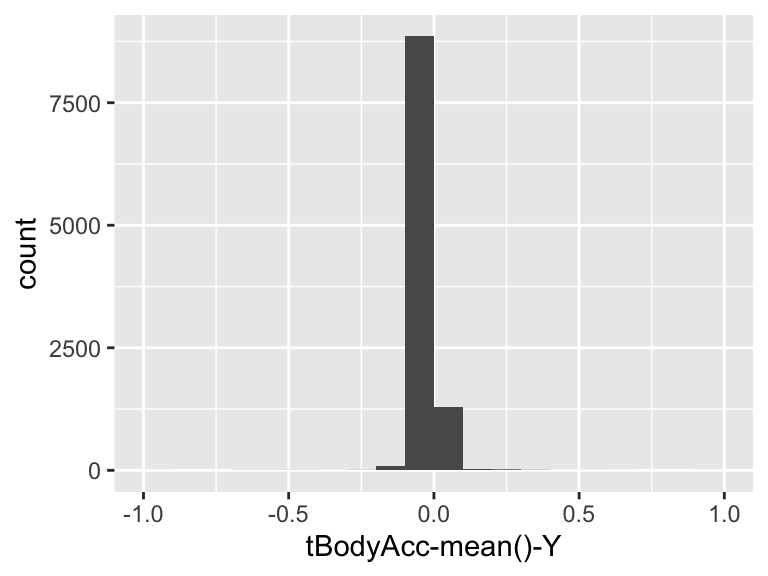

## tBodyAcc-mean()-Z

| Feature | Result |
| --- | --- |
| Variable type | numeric |
| Number of missing obs. | 0 (0 %) |
| Number of unique values | 10293 |
| Median | -0.11 |
| 1st and 3rd quartiles | -0.12; -0.1 |
| Min. and max. | -1; 1 |

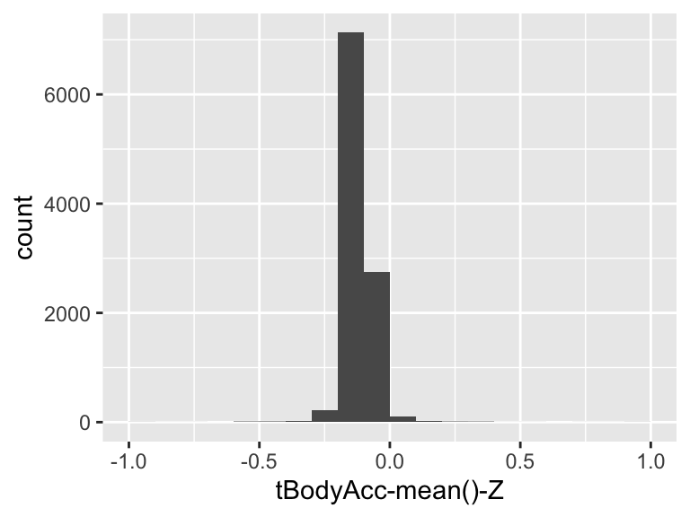

## tBodyAcc-std()-X

| Feature | Result |
| --- | --- |
| Variable type | numeric |
| Number of missing obs. | 0 (0 %) |
| Number of unique values | 10295 |
| Median | -0.94 |
| 1st and 3rd quartiles | -0.99; -0.25 |
| Min. and max. | -1; 1 |

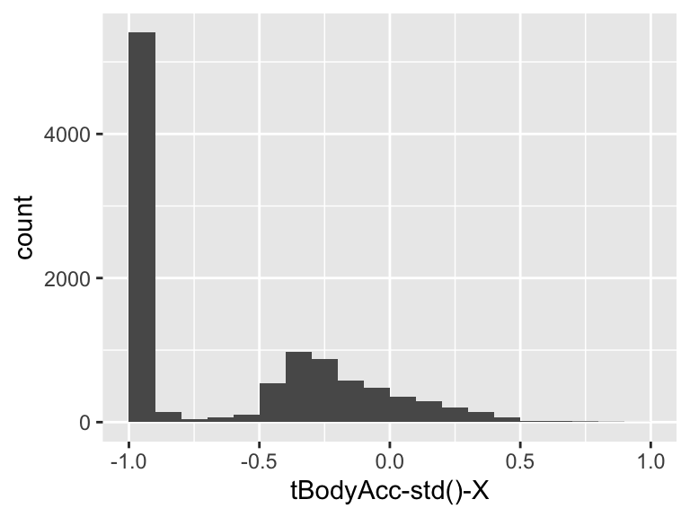

## tBodyAcc-std()-Y

| Feature | Result |
| --- | --- |
| Variable type | numeric |
| Number of missing obs. | 0 (0 %) |
| Number of unique values | 10297 |
| Median | -0.84 |
| 1st and 3rd quartiles | -0.98; -0.06 |
| Min. and max. | -1; 1 |

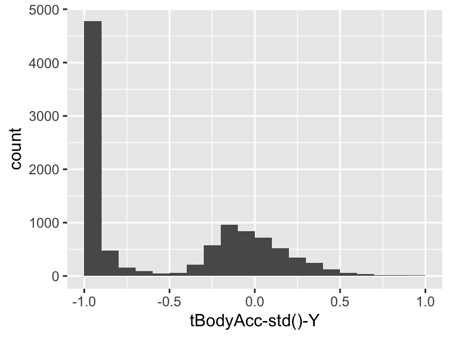

## tBodyAcc-std()-Z

| Feature | Result |
| --- | --- |
| Variable type | numeric |
| Number of missing obs. | 0 (0 %) |
| Number of unique values | 10297 |
| Median | -0.85 |
| 1st and 3rd quartiles | -0.98; -0.28 |
| Min. and max. | -1; 1 |

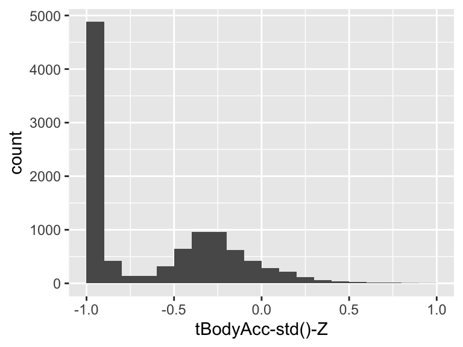

## tGravityAcc-mean()-X

| Feature | Result |
| --- | --- |
| Variable type | numeric |
| Number of missing obs. | 0 (0 %) |
| Number of unique values | 10296 |
| Median | 0.92 |
| 1st and 3rd quartiles | 0.81; 0.95 |
| Min. and max. | -1; 1 |

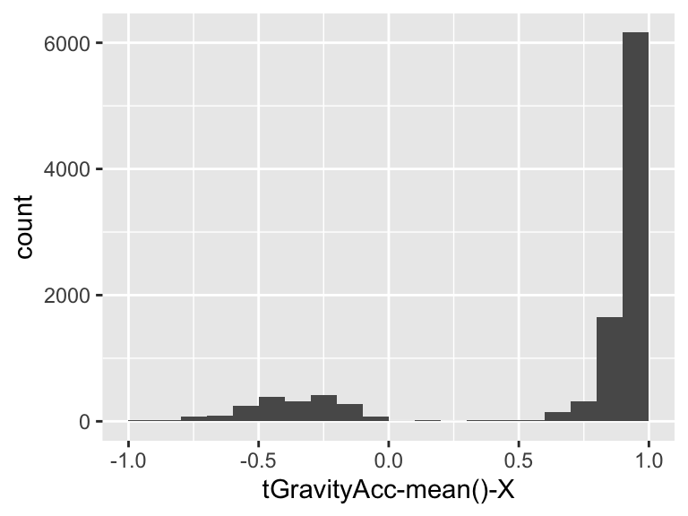

## tGravityAcc-mean()-Y

| Feature | Result |
| --- | --- |
| Variable type | numeric |
| Number of missing obs. | 0 (0 %) |
| Number of unique values | 10298 |
| Median | -0.14 |
| 1st and 3rd quartiles | -0.24; 0.12 |
| Min. and max. | -1; 1 |

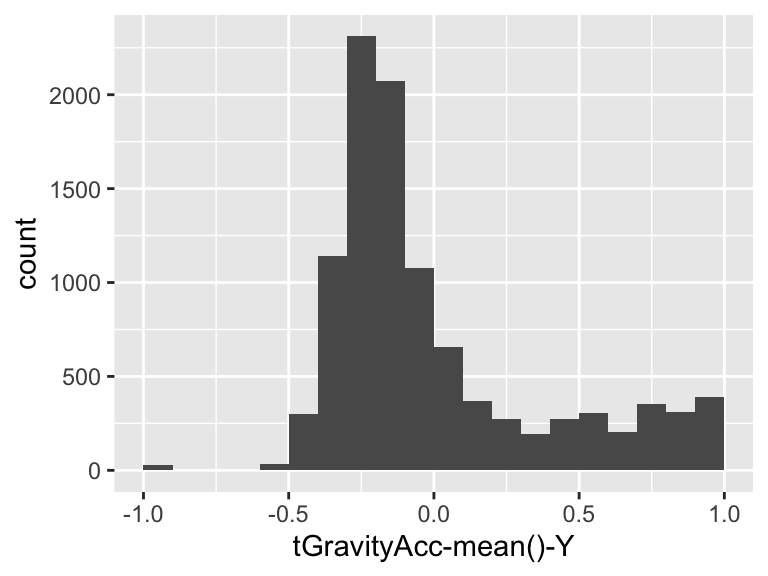

## tGravityAcc-mean()-Z

| Feature | Result |
| --- | --- |
| Variable type | numeric |
| Number of missing obs. | 0 (0 %) |
| Number of unique values | 10299 |
| Median | 0.04 |
| 1st and 3rd quartiles | -0.12; 0.22 |
| Min. and max. | -1; 1 |

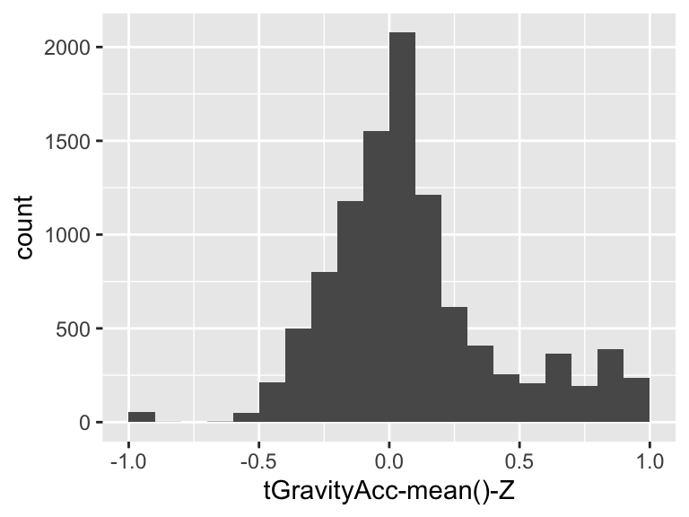

## tGravityAcc-std()-X

| Feature | Result |
| --- | --- |
| Variable type | numeric |
| Number of missing obs. | 0 (0 %) |
| Number of unique values | 10288 |
| Median | -0.98 |
| 1st and 3rd quartiles | -0.99; -0.96 |
| Min. and max. | -1; 1 |

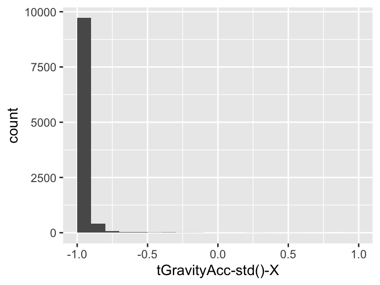

## tGravityAcc-std()-Y

| Feature | Result |
| --- | --- |
| Variable type | numeric |
| Number of missing obs. | 0 (0 %) |
| Number of unique values | 10293 |
| Median | -0.98 |
| 1st and 3rd quartiles | -0.99; -0.95 |
| Min. and max. | -1; 1 |

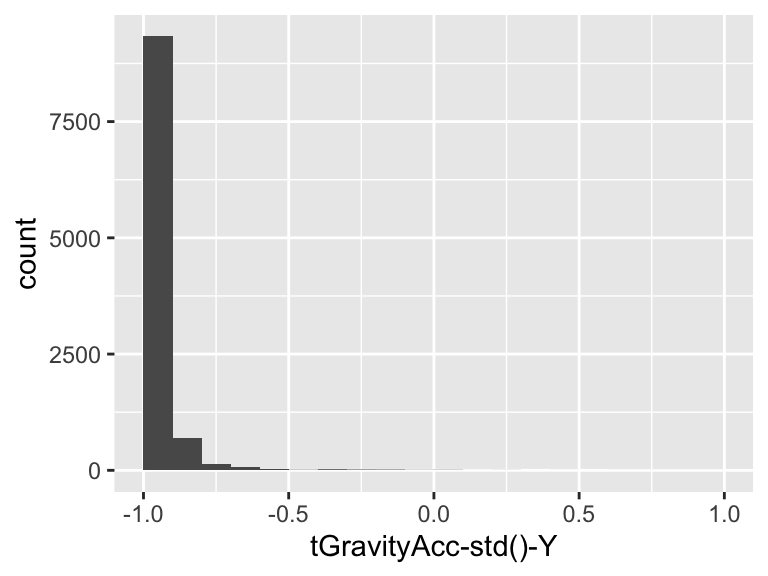

## tGravityAcc-std()-Z

| Feature | Result |
| --- | --- |
| Variable type | numeric |
| Number of missing obs. | 0 (0 %) |
| Number of unique values | 10296 |
| Median | -0.97 |
| 1st and 3rd quartiles | -0.99; -0.93 |
| Min. and max. | -1; 1 |

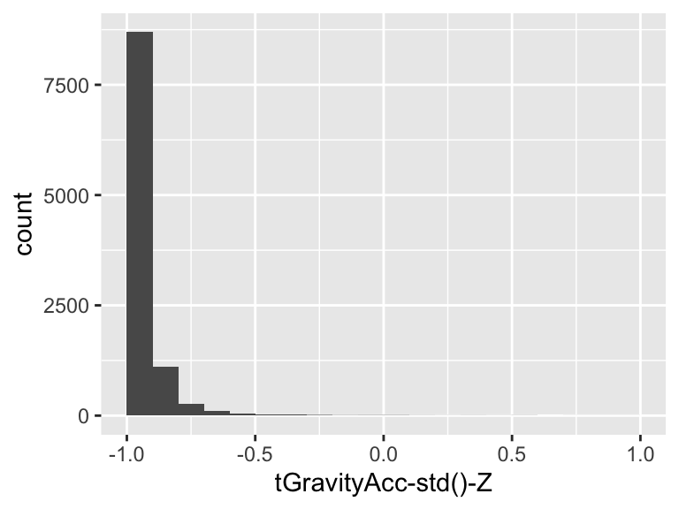

## tBodyAccJerk-mean()-X

| Feature | Result |
| --- | --- |
| Variable type | numeric |
| Number of missing obs. | 0 (0 %) |
| Number of unique values | 10299 |
| Median | 0.08 |
| 1st and 3rd quartiles | 0.06; 0.09 |
| Min. and max. | -1; 1 |

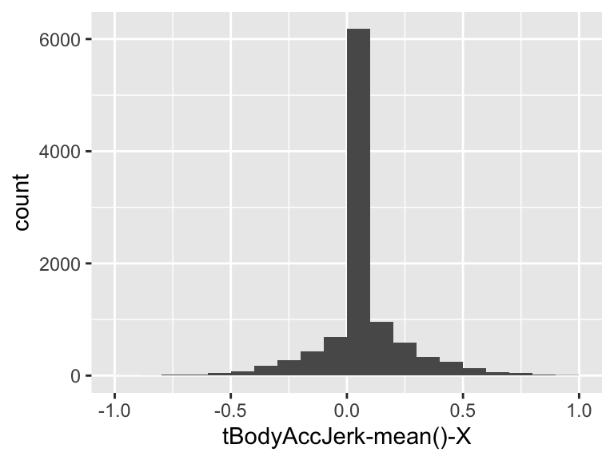

## tBodyAccJerk-mean()-Y

| Feature | Result |
| --- | --- |
| Variable type | numeric |
| Number of missing obs. | 0 (0 %) |
| Number of unique values | 10299 |
| Median | 0.01 |
| 1st and 3rd quartiles | -0.02; 0.03 |
| Min. and max. | -1; 1 |

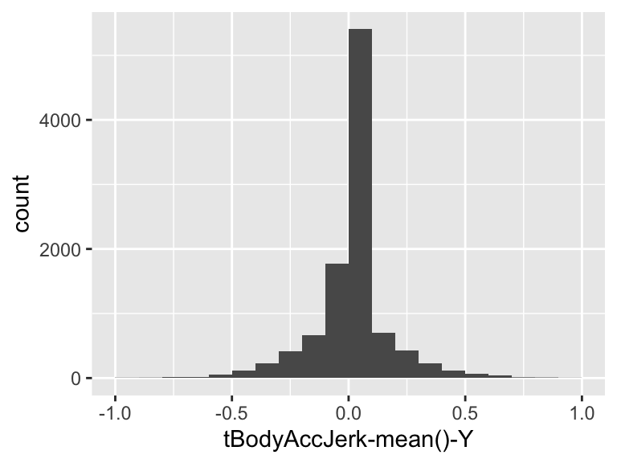

## tBodyAccJerk-mean()-Z

| Feature | Result |
| --- | --- |
| Variable type | numeric |
| Number of missing obs. | 0 (0 %) |
| Number of unique values | 10299 |
| Median | 0 |
| 1st and 3rd quartiles | -0.03; 0.02 |
| Min. and max. | -1; 1 |

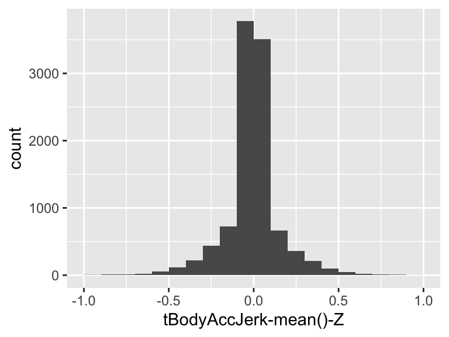

## tBodyAccJerk-std()-X

| Feature | Result |
| --- | --- |
| Variable type | numeric |
| Number of missing obs. | 0 (0 %) |
| Number of unique values | 10290 |
| Median | -0.95 |
| 1st and 3rd quartiles | -0.99; -0.29 |
| Min. and max. | -1; 1 |

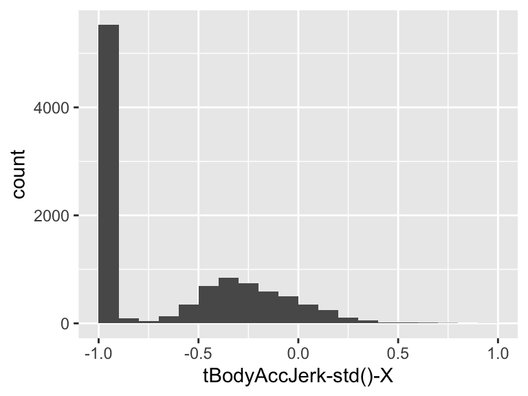

## tBodyAccJerk-std()-Y

| Feature | Result |
| --- | --- |
| Variable type | numeric |
| Number of missing obs. | 0 (0 %) |
| Number of unique values | 10296 |
| Median | -0.93 |
| 1st and 3rd quartiles | -0.99; -0.22 |
| Min. and max. | -1; 1 |

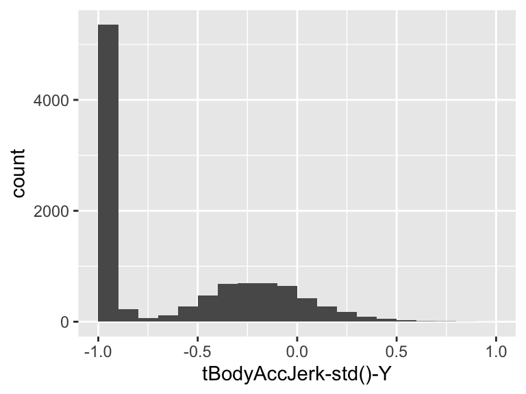

## tBodyAccJerk-std()-Z

| Feature | Result |
| --- | --- |
| Variable type | numeric |
| Number of missing obs. | 0 (0 %) |
| Number of unique values | 10293 |
| Median | -0.95 |
| 1st and 3rd quartiles | -0.99; -0.55 |
| Min. and max. | -1; 1 |

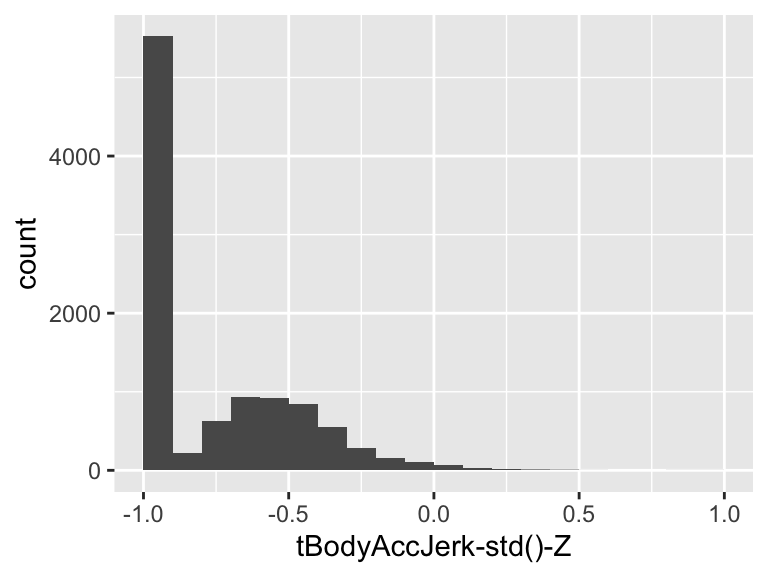

## tBodyGyro-mean()-X

| Feature | Result |
| --- | --- |
| Variable type | numeric |
| Number of missing obs. | 0 (0 %) |
| Number of unique values | 10298 |
| Median | -0.03 |
| 1st and 3rd quartiles | -0.05; -0.01 |
| Min. and max. | -1; 1 |

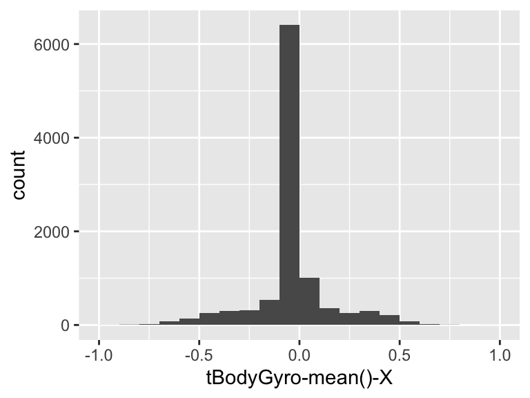

## tBodyGyro-mean()-Y

| Feature | Result |
| --- | --- |
| Variable type | numeric |
| Number of missing obs. | 0 (0 %) |
| Number of unique values | 10299 |
| Median | -0.07 |
| 1st and 3rd quartiles | -0.1; -0.05 |
| Min. and max. | -1; 1 |

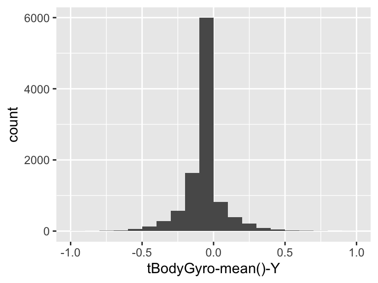

## tBodyGyro-mean()-Z

| Feature | Result |
| --- | --- |
| Variable type | numeric |
| Number of missing obs. | 0 (0 %) |
| Number of unique values | 10297 |
| Median | 0.09 |
| 1st and 3rd quartiles | 0.06; 0.11 |
| Min. and max. | -1; 1 |

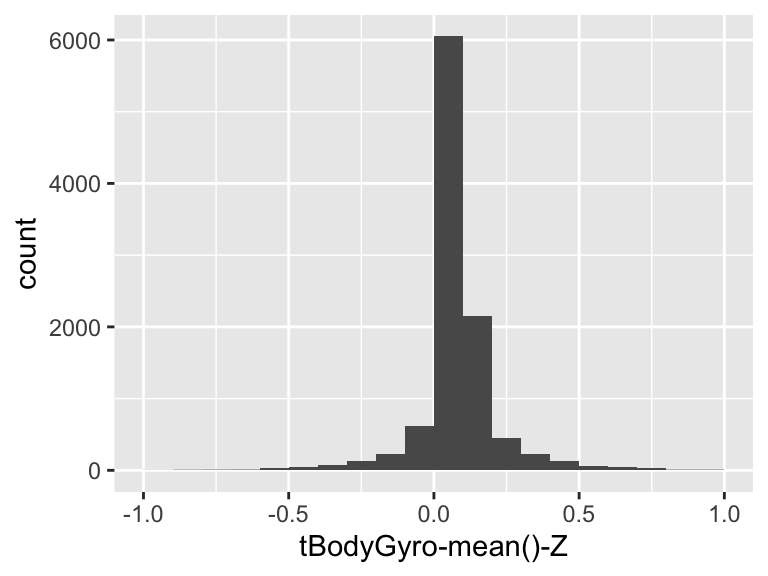

## tBodyGyro-std()-X

| Feature | Result |
| --- | --- |
| Variable type | numeric |
| Number of missing obs. | 0 (0 %) |
| Number of unique values | 10292 |
| Median | -0.9 |
| 1st and 3rd quartiles | -0.99; -0.48 |
| Min. and max. | -1; 1 |

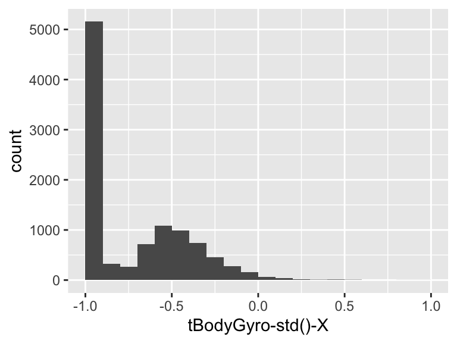

## tBodyGyro-std()-Y

| Feature | Result |
| --- | --- |
| Variable type | numeric |
| Number of missing obs. | 0 (0 %) |
| Number of unique values | 10296 |
| Median | -0.91 |
| 1st and 3rd quartiles | -0.98; -0.45 |
| Min. and max. | -1; 1 |

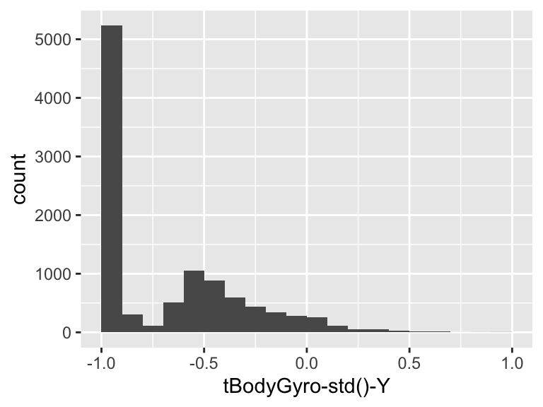

## tBodyGyro-std()-Z

| Feature | Result |
| --- | --- |
| Variable type | numeric |
| Number of missing obs. | 0 (0 %) |
| Number of unique values | 10296 |
| Median | -0.88 |
| 1st and 3rd quartiles | -0.99; -0.34 |
| Min. and max. | -1; 1 |

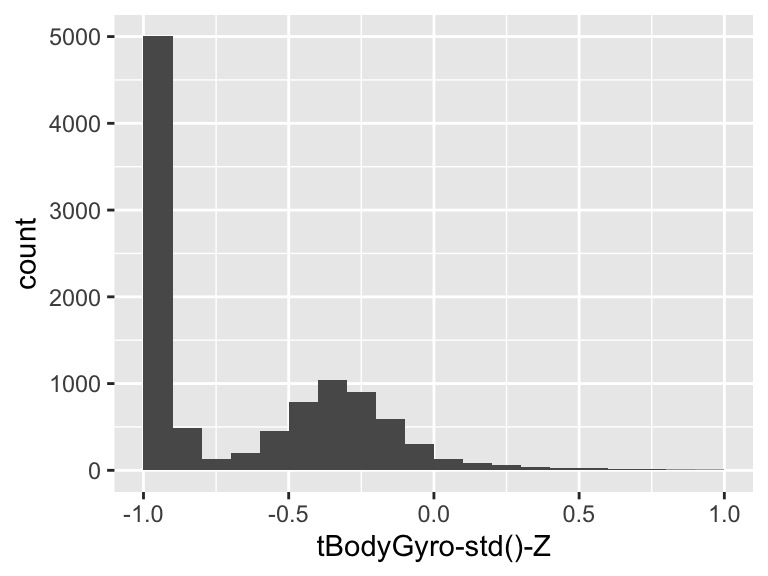

## tBodyGyroJerk-mean()-X

| Feature | Result |
| --- | --- |
| Variable type | numeric |
| Number of missing obs. | 0 (0 %) |
| Number of unique values | 10295 |
| Median | -0.1 |
| 1st and 3rd quartiles | -0.12; -0.08 |
| Min. and max. | -1; 1 |

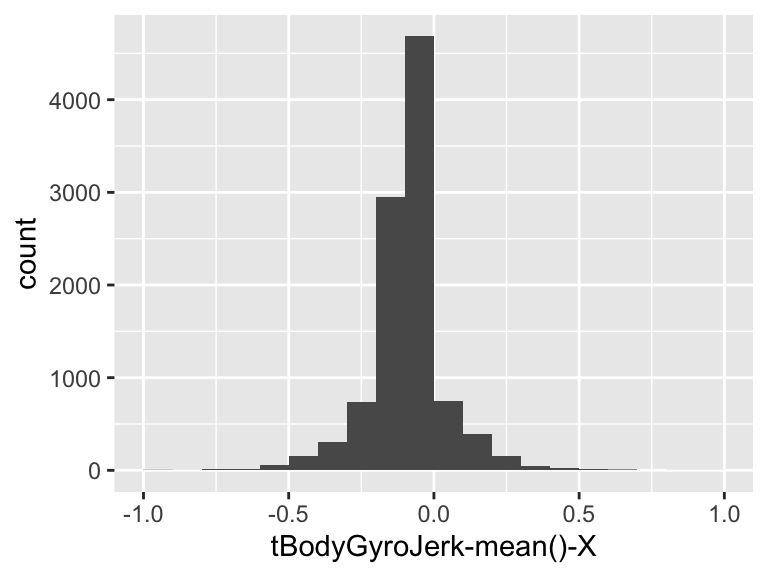

## tBodyGyroJerk-mean()-Y

| Feature | Result |
| --- | --- |
| Variable type | numeric |
| Number of missing obs. | 0 (0 %) |
| Number of unique values | 10299 |
| Median | -0.04 |
| 1st and 3rd quartiles | -0.06; -0.03 |
| Min. and max. | -1; 1 |

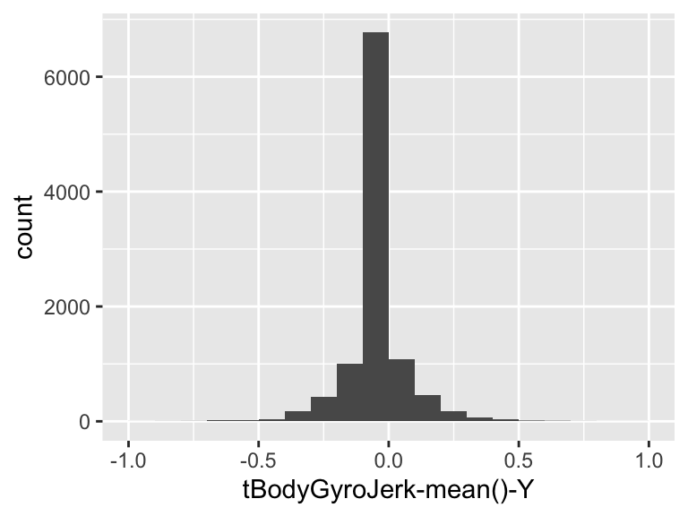

## tBodyGyroJerk-mean()-Z

| Feature | Result |
| --- | --- |
| Variable type | numeric |
| Number of missing obs. | 0 (0 %) |
| Number of unique values | 10298 |
| Median | -0.05 |
| 1st and 3rd quartiles | -0.08; -0.03 |
| Min. and max. | -1; 1 |

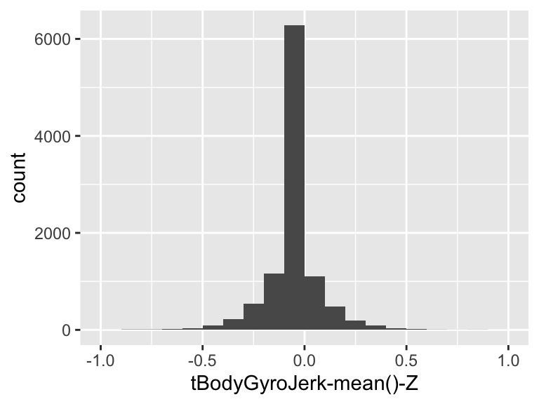

## tBodyGyroJerk-std()-X

| Feature | Result |
| --- | --- |
| Variable type | numeric |
| Number of missing obs. | 0 (0 %) |
| Number of unique values | 10292 |
| Median | -0.93 |
| 1st and 3rd quartiles | -0.99; -0.49 |
| Min. and max. | -1; 1 |

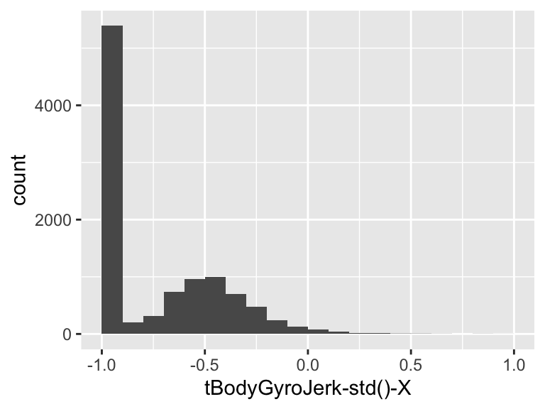

## tBodyGyroJerk-std()-Y

| Feature | Result |
| --- | --- |
| Variable type | numeric |
| Number of missing obs. | 0 (0 %) |
| Number of unique values | 10295 |
| Median | -0.95 |
| 1st and 3rd quartiles | -0.99; -0.63 |
| Min. and max. | -1; 1 |

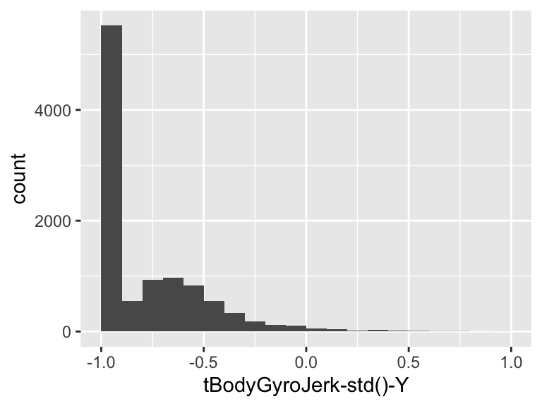

## tBodyGyroJerk-std()-Z

| Feature | Result |
| --- | --- |
| Variable type | numeric |
| Number of missing obs. | 0 (0 %) |
| Number of unique values | 10291 |
| Median | -0.95 |
| 1st and 3rd quartiles | -0.99; -0.51 |
| Min. and max. | -1; 1 |

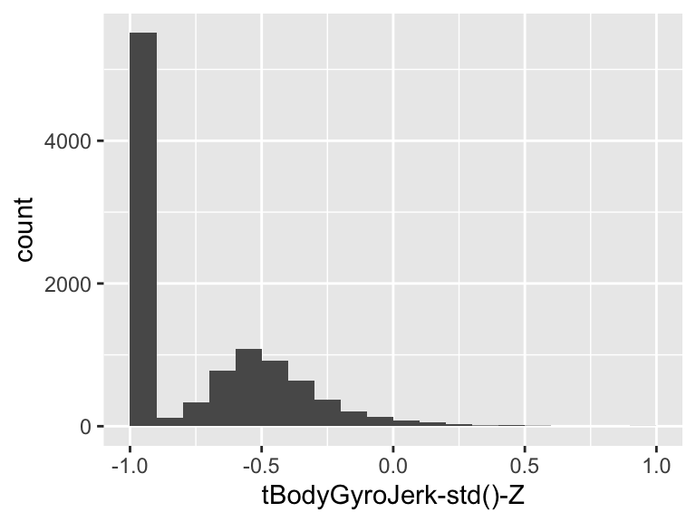

## tBodyAccMag-mean()

| Feature | Result |
| --- | --- |
| Variable type | numeric |
| Number of missing obs. | 0 (0 %) |
| Number of unique values | 10296 |
| Median | -0.87 |
| 1st and 3rd quartiles | -0.98; -0.12 |
| Min. and max. | -1; 1 |

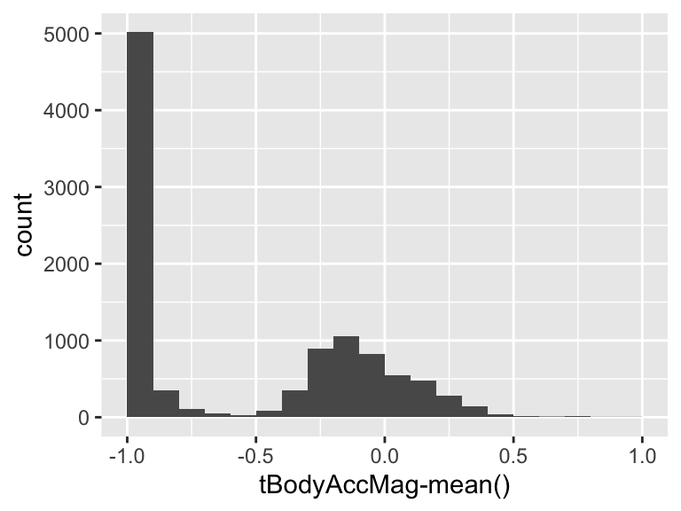

## tBodyAccMag-std()

| Feature | Result |
| --- | --- |
| Variable type | numeric |
| Number of missing obs. | 0 (0 %) |
| Number of unique values | 10294 |
| Median | -0.84 |
| 1st and 3rd quartiles | -0.98; -0.24 |
| Min. and max. | -1; 1 |

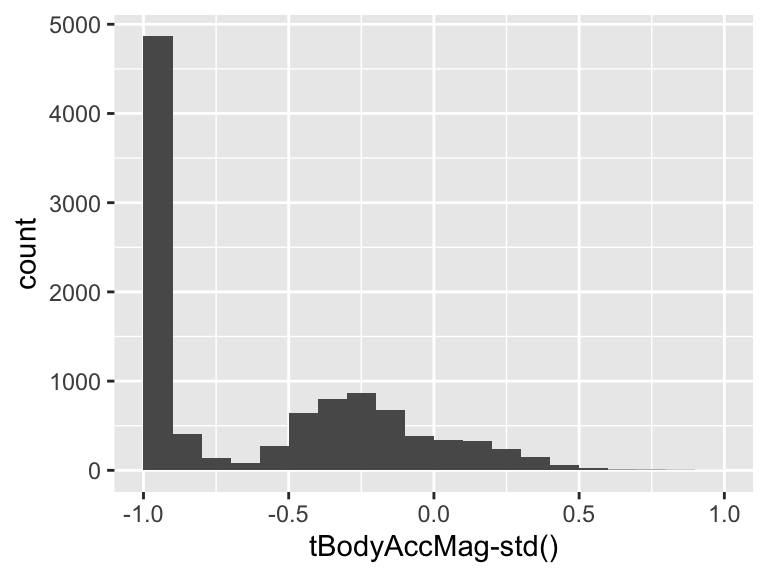

## tGravityAccMag-mean()

| Feature | Result |
| --- | --- |
| Variable type | numeric |
| Number of missing obs. | 0 (0 %) |
| Number of unique values | 10296 |
| Median | -0.87 |
| 1st and 3rd quartiles | -0.98; -0.12 |
| Min. and max. | -1; 1 |

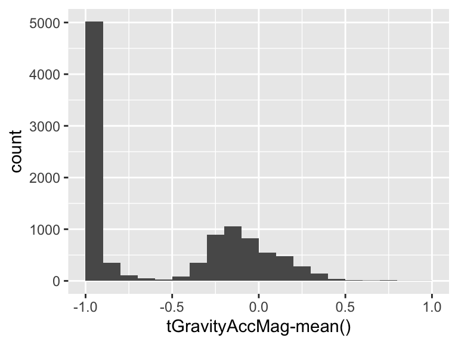

## tGravityAccMag-std()

| Feature | Result |
| --- | --- |
| Variable type | numeric |
| Number of missing obs. | 0 (0 %) |
| Number of unique values | 10294 |
| Median | -0.84 |
| 1st and 3rd quartiles | -0.98; -0.24 |
| Min. and max. | -1; 1 |

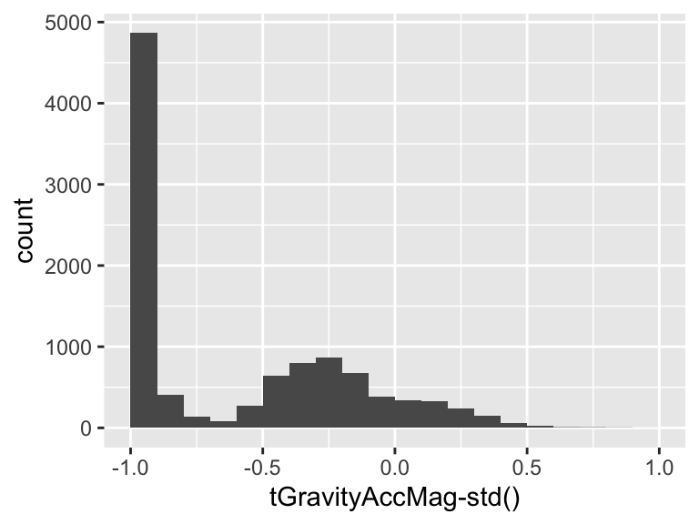

## tBodyAccJerkMag-mean()

| Feature | Result |
| --- | --- |
| Variable type | numeric |
| Number of missing obs. | 0 (0 %) |
| Number of unique values | 10292 |
| Median | -0.95 |
| 1st and 3rd quartiles | -0.99; -0.3 |
| Min. and max. | -1; 1 |

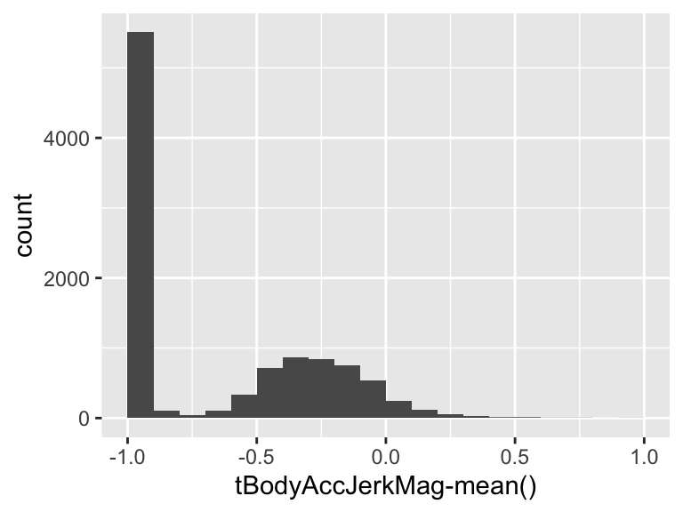

## tBodyAccJerkMag-std()

| Feature | Result |
| --- | --- |
| Variable type | numeric |
| Number of missing obs. | 0 (0 %) |
| Number of unique values | 10294 |
| Median | -0.93 |
| 1st and 3rd quartiles | -0.99; -0.27 |
| Min. and max. | -1; 1 |

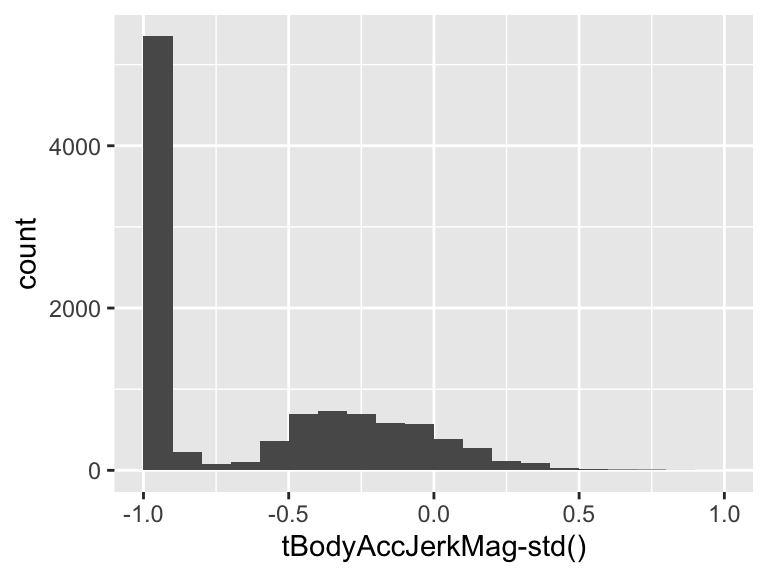

## tBodyGyroMag-mean()

| Feature | Result |
| --- | --- |
| Variable type | numeric |
| Number of missing obs. | 0 (0 %) |
| Number of unique values | 10298 |
| Median | -0.82 |
| 1st and 3rd quartiles | -0.98; -0.25 |
| Min. and max. | -1; 1 |

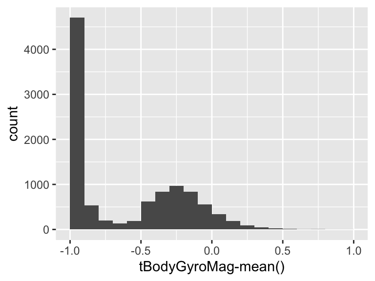

## tBodyGyroMag-std()

| Feature | Result |
| --- | --- |
| Variable type | numeric |
| Number of missing obs. | 0 (0 %) |
| Number of unique values | 10298 |
| Median | -0.83 |
| 1st and 3rd quartiles | -0.98; -0.39 |
| Min. and max. | -1; 1 |

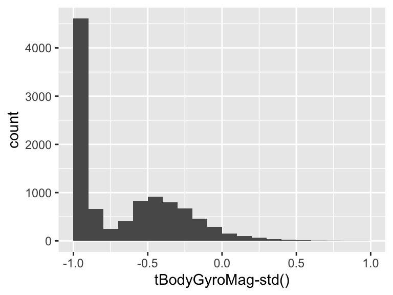

## tBodyGyroJerkMag-mean()

| Feature | Result |
| --- | --- |
| Variable type | numeric |
| Number of missing obs. | 0 (0 %) |
| Number of unique values | 10293 |
| Median | -0.96 |
| 1st and 3rd quartiles | -0.99; -0.55 |
| Min. and max. | -1; 1 |

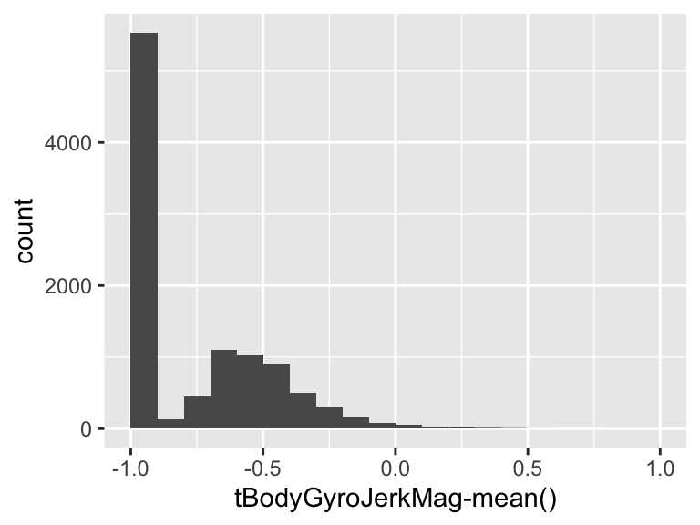

## tBodyGyroJerkMag-std()

| Feature | Result |
| --- | --- |
| Variable type | numeric |
| Number of missing obs. | 0 (0 %) |
| Number of unique values | 10297 |
| Median | -0.94 |
| 1st and 3rd quartiles | -0.99; -0.61 |
| Min. and max. | -1; 1 |

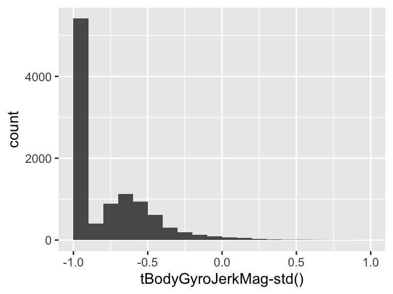

## fBodyAcc-mean()-X

| Feature | Result |
| --- | --- |
| Variable type | numeric |
| Number of missing obs. | 0 (0 %) |
| Number of unique values | 10295 |
| Median | -0.95 |
| 1st and 3rd quartiles | -0.99; -0.26 |
| Min. and max. | -1; 1 |

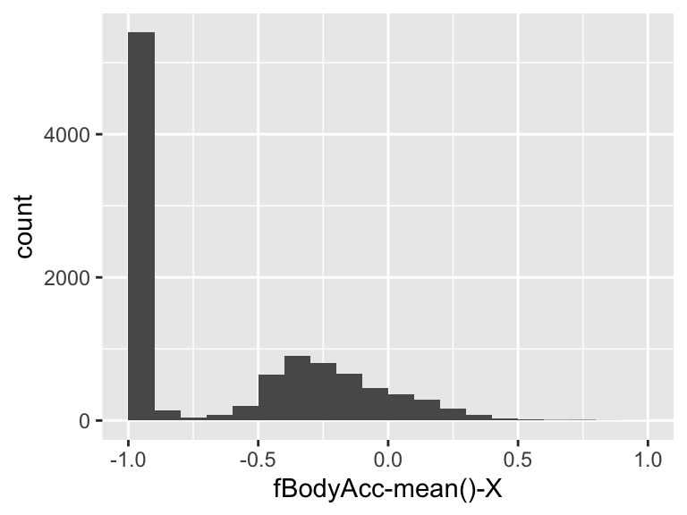

## fBodyAcc-mean()-Y

| Feature | Result |
| --- | --- |
| Variable type | numeric |
| Number of missing obs. | 0 (0 %) |
| Number of unique values | 10292 |
| Median | -0.86 |
| 1st and 3rd quartiles | -0.98; -0.1 |
| Min. and max. | -1; 1 |

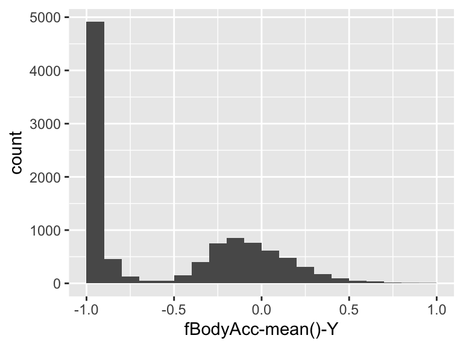

## fBodyAcc-mean()-Z

| Feature | Result |
| --- | --- |
| Variable type | numeric |
| Number of missing obs. | 0 (0 %) |
| Number of unique values | 10295 |
| Median | -0.9 |
| 1st and 3rd quartiles | -0.98; -0.37 |
| Min. and max. | -1; 1 |

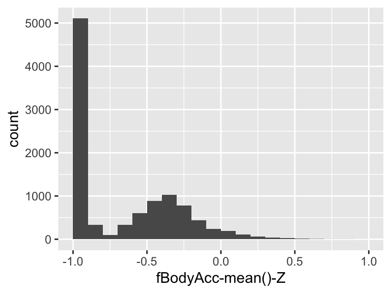

## fBodyAcc-std()-X

| Feature | Result |
| --- | --- |
| Variable type | numeric |
| Number of missing obs. | 0 (0 %) |
| Number of unique values | 10294 |
| Median | -0.94 |
| 1st and 3rd quartiles | -0.99; -0.25 |
| Min. and max. | -1; 1 |

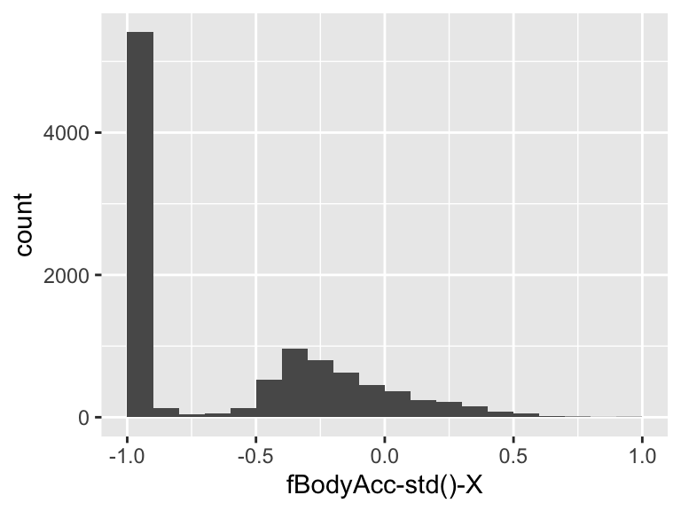

## fBodyAcc-std()-Y

| Feature | Result |
| --- | --- |
| Variable type | numeric |
| Number of missing obs. | 0 (0 %) |
| Number of unique values | 10297 |
| Median | -0.83 |
| 1st and 3rd quartiles | -0.98; -0.09 |
| Min. and max. | -1; 1 |

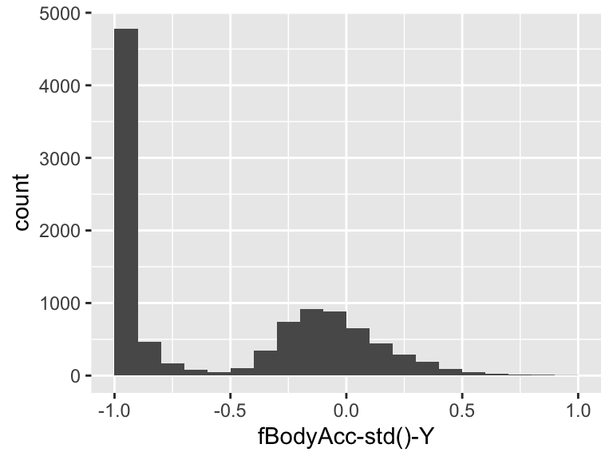

## fBodyAcc-std()-Z

| Feature | Result |
| --- | --- |
| Variable type | numeric |
| Number of missing obs. | 0 (0 %) |
| Number of unique values | 10296 |
| Median | -0.84 |
| 1st and 3rd quartiles | -0.98; -0.3 |
| Min. and max. | -1; 1 |

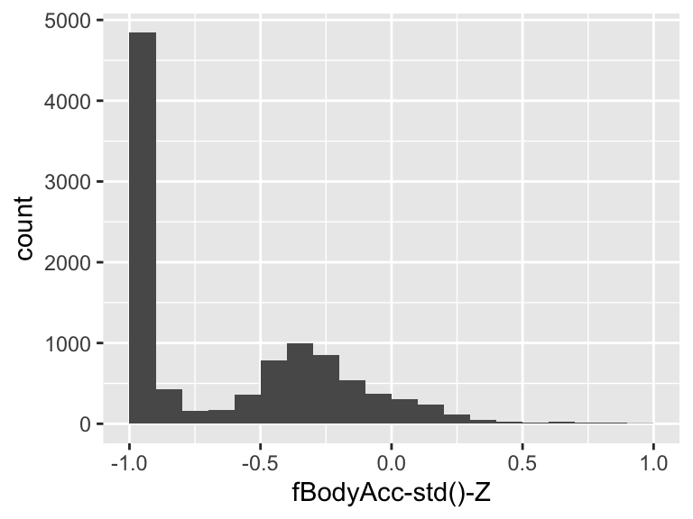

## fBodyAcc-meanFreq()-X

| Feature | Result |
| --- | --- |
| Variable type | numeric |
| Number of missing obs. | 0 (0 %) |
| Number of unique values | 10299 |
| Median | -0.24 |
| 1st and 3rd quartiles | -0.42; -0.02 |
| Min. and max. | -1; 1 |

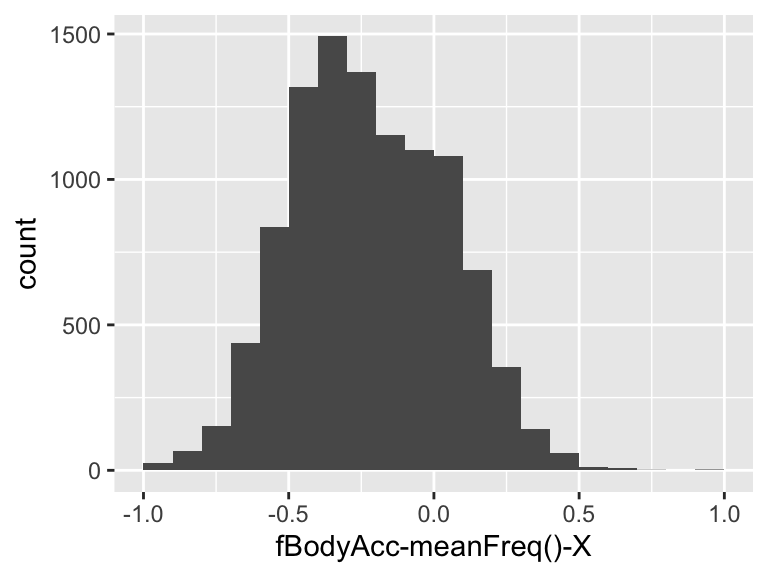

## fBodyAcc-meanFreq()-Y

| Feature | Result |
| --- | --- |
| Variable type | numeric |
| Number of missing obs. | 0 (0 %) |
| Number of unique values | 10299 |
| Median | 0 |
| 1st and 3rd quartiles | -0.14; 0.18 |
| Min. and max. | -1; 1 |

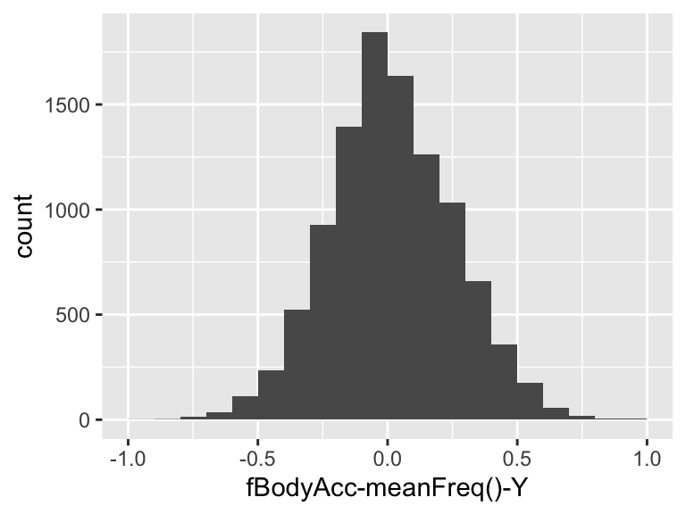

## fBodyAcc-meanFreq()-Z

| Feature | Result |
| --- | --- |
| Variable type | numeric |
| Number of missing obs. | 0 (0 %) |
| Number of unique values | 10299 |
| Median | 0.06 |
| 1st and 3rd quartiles | -0.14; 0.25 |
| Min. and max. | -1; 1 |

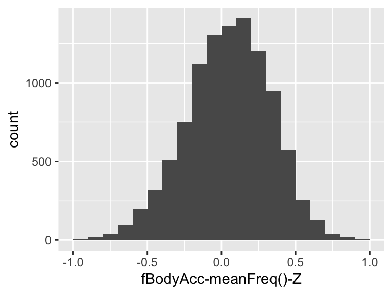

## fBodyAccJerk-mean()-X

| Feature | Result |
| --- | --- |
| Variable type | numeric |
| Number of missing obs. | 0 (0 %) |
| Number of unique values | 10293 |
| Median | -0.95 |
| 1st and 3rd quartiles | -0.99; -0.33 |
| Min. and max. | -1; 1 |

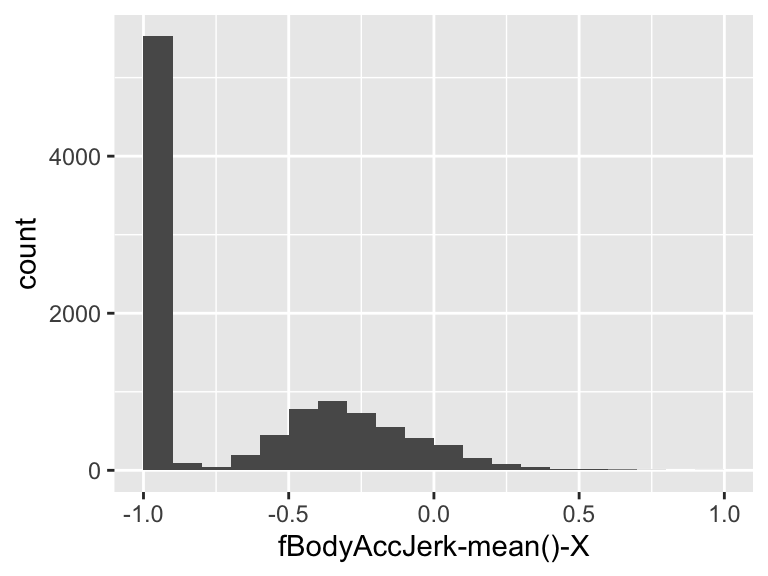

## fBodyAccJerk-mean()-Y

| Feature | Result |
| --- | --- |
| Variable type | numeric |
| Number of missing obs. | 0 (0 %) |
| Number of unique values | 10296 |
| Median | -0.93 |
| 1st and 3rd quartiles | -0.98; -0.26 |
| Min. and max. | -1; 1 |

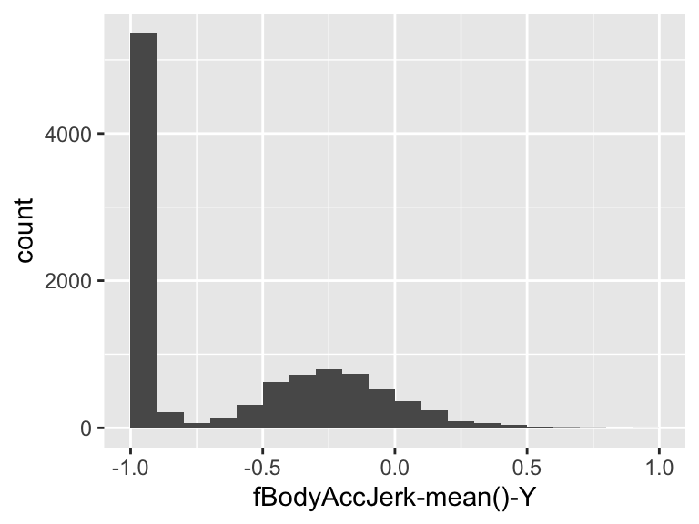

## fBodyAccJerk-mean()-Z

| Feature | Result |
| --- | --- |
| Variable type | numeric |
| Number of missing obs. | 0 (0 %) |
| Number of unique values | 10294 |
| Median | -0.95 |
| 1st and 3rd quartiles | -0.99; -0.51 |
| Min. and max. | -1; 1 |

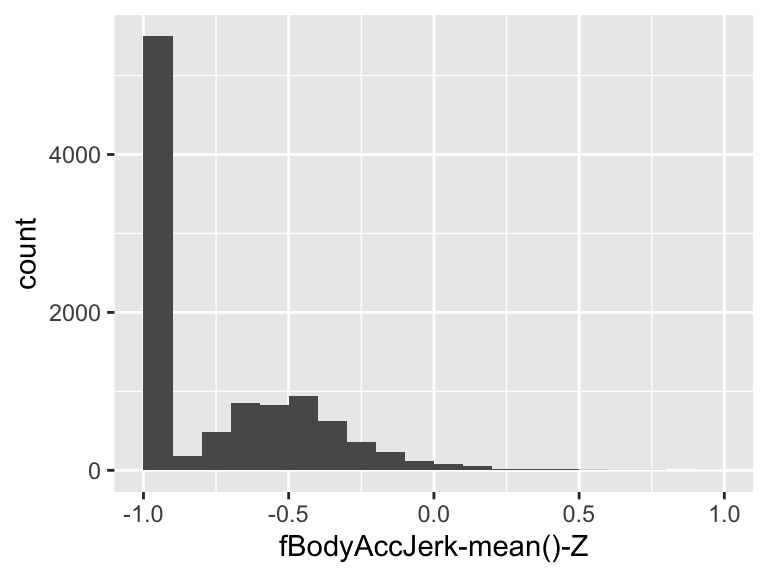

## fBodyAccJerk-std()-X

| Feature | Result |
| --- | --- |
| Variable type | numeric |
| Number of missing obs. | 0 (0 %) |
| Number of unique values | 10291 |
| Median | -0.96 |
| 1st and 3rd quartiles | -0.99; -0.32 |
| Min. and max. | -1; 1 |

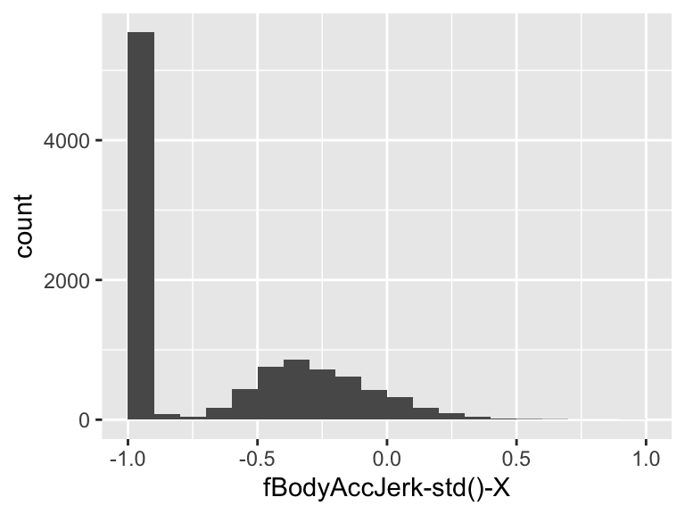

## fBodyAccJerk-std()-Y

| Feature | Result |
| --- | --- |
| Variable type | numeric |
| Number of missing obs. | 0 (0 %) |
| Number of unique values | 10294 |
| Median | -0.93 |
| 1st and 3rd quartiles | -0.99; -0.24 |
| Min. and max. | -1; 1 |

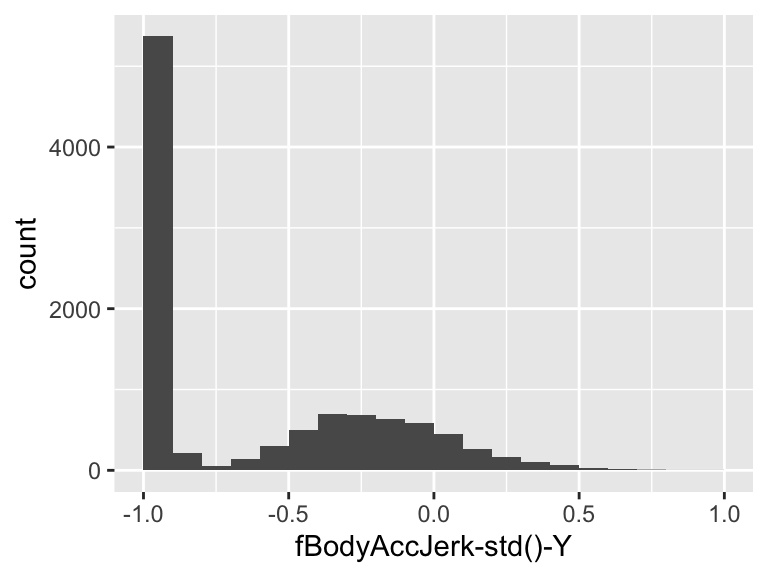

## fBodyAccJerk-std()-Z

| Feature | Result |
| --- | --- |
| Variable type | numeric |
| Number of missing obs. | 0 (0 %) |
| Number of unique values | 10290 |
| Median | -0.96 |
| 1st and 3rd quartiles | -0.99; -0.59 |
| Min. and max. | -1; 1 |

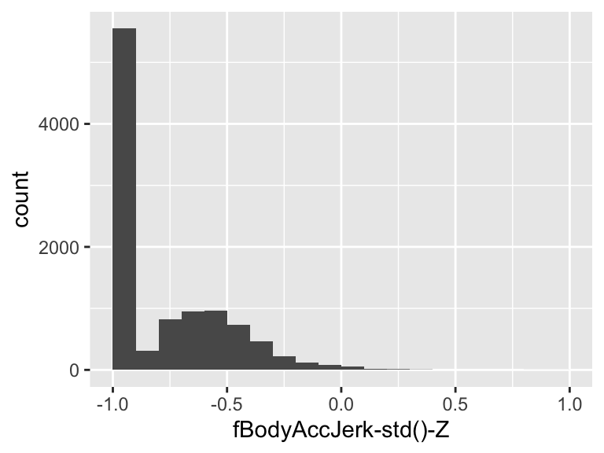

## fBodyAccJerk-meanFreq()-X

| Feature | Result |
| --- | --- |
| Variable type | numeric |
| Number of missing obs. | 0 (0 %) |
| Number of unique values | 10298 |
| Median | -0.05 |
| 1st and 3rd quartiles | -0.3; 0.2 |
| Min. and max. | -1; 1 |

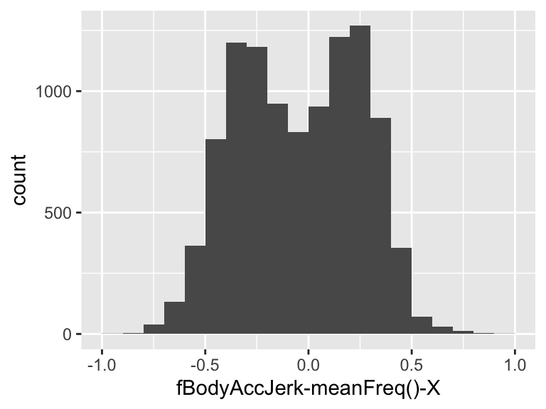

## fBodyAccJerk-meanFreq()-Y

| Feature | Result |
| --- | --- |
| Variable type | numeric |
| Number of missing obs. | 0 (0 %) |
| Number of unique values | 10299 |
| Median | -0.24 |
| 1st and 3rd quartiles | -0.43; 0.01 |
| Min. and max. | -1; 1 |

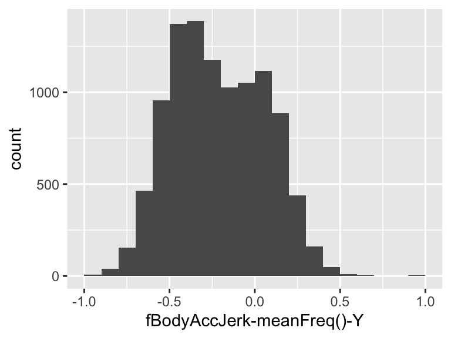

## fBodyAccJerk-meanFreq()-Z

| Feature | Result |
| --- | --- |
| Variable type | numeric |
| Number of missing obs. | 0 (0 %) |
| Number of unique values | 10298 |
| Median | -0.1 |
| 1st and 3rd quartiles | -0.33; 0.09 |
| Min. and max. | -1; 1 |

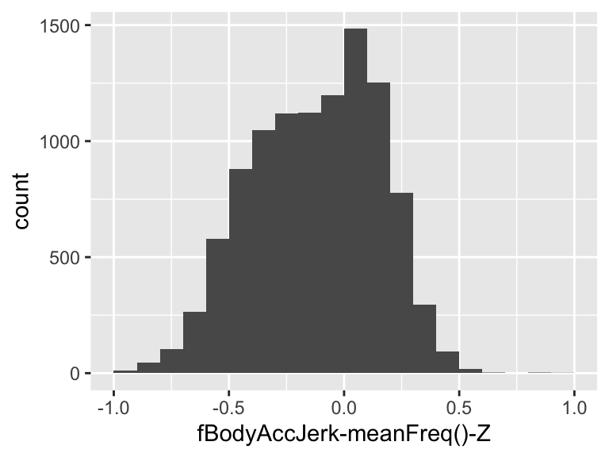

## fBodyGyro-mean()-X

| Feature | Result |
| --- | --- |
| Variable type | numeric |
| Number of missing obs. | 0 (0 %) |
| Number of unique values | 10297 |
| Median | -0.89 |
| 1st and 3rd quartiles | -0.99; -0.38 |
| Min. and max. | -1; 1 |

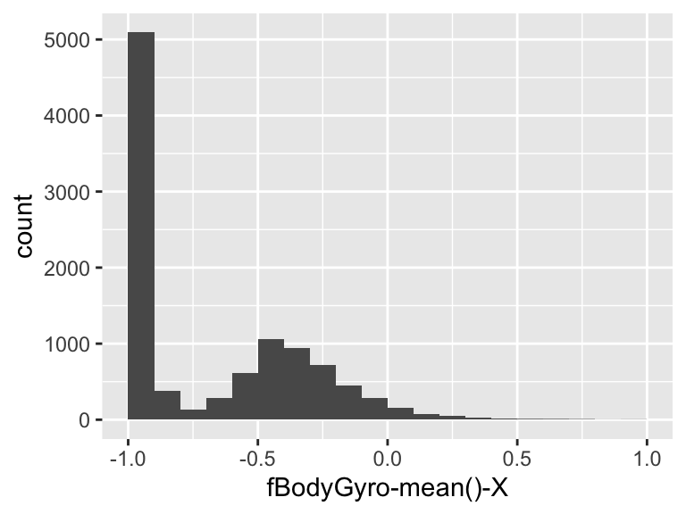

## fBodyGyro-mean()-Y

| Feature | Result |
| --- | --- |
| Variable type | numeric |
| Number of missing obs. | 0 (0 %) |
| Number of unique values | 10296 |
| Median | -0.92 |
| 1st and 3rd quartiles | -0.98; -0.47 |
| Min. and max. | -1; 1 |

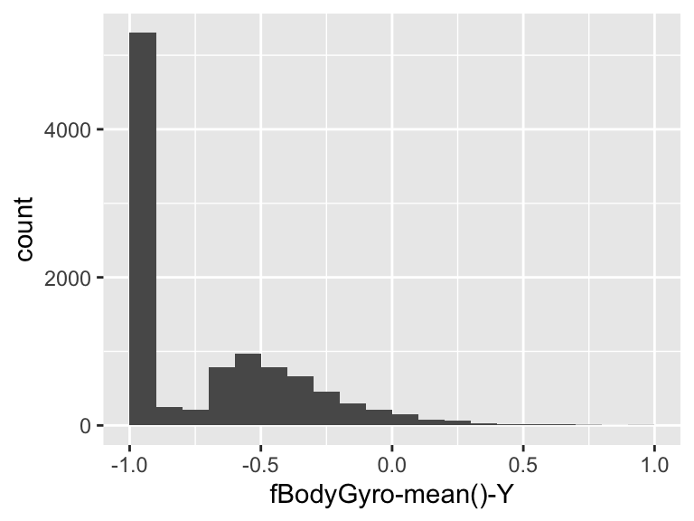

## fBodyGyro-mean()-Z

| Feature | Result |
| --- | --- |
| Variable type | numeric |
| Number of missing obs. | 0 (0 %) |
| Number of unique values | 10297 |
| Median | -0.89 |
| 1st and 3rd quartiles | -0.99; -0.32 |
| Min. and max. | -1; 1 |

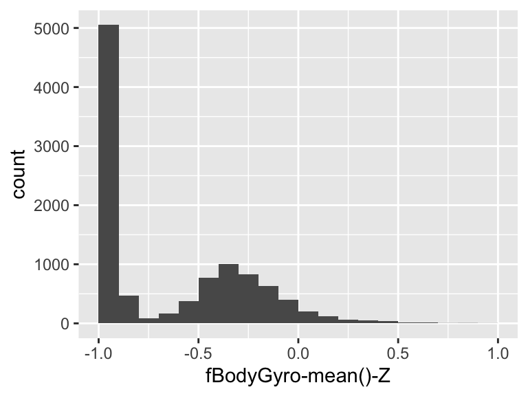